# Data Science and Data Analytics

Introduction to Data Science

Julian Amon, PhD

Charlotte Fresenius Privatuniversität

March 13, 2026

# What is Data Science?

## Data Science – A sexy profession in 2012?

[figure not shown]

Source: [Harvard Business Review](https://hbr.org/2012/10/data-scientist-the-sexiest-job-of-the-21st-century) in October 2012

## Data Science – A sexy profession today?

[figure not shown]

Source: [Harvard Business Review](https://hbr.org/2022/07/is-data-scientist-still-the-sexiest-job-of-the-21st-century) in July 2022

## What is Data Science?

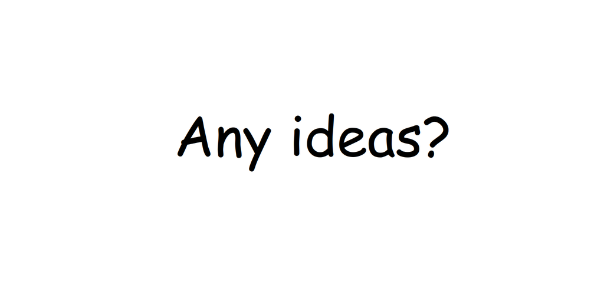

## What is Data Science?

**Data science** is an interdisciplinary academic field that combines statistics, mathematics and computing with specific subject matter expertise to uncover actionable insights hidden in an organization’s data.

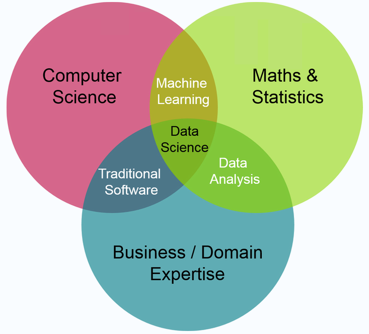

## A brief history of Data Science

- **1962**: Statistician John Tukey describes a field he calls *data analysis*, similar to what we now understand to be data science.
- **1974**: Computer scientist Peter Naur proposes the term *data science*, but in a different sense to today, namely as an alternative name for computer science.
- **1992**: Conference participants at the University of Montpellier II acknowledge the emergence of a new, inherently interdisciplinary field called *data science* focused on gaining insight from very diverse types of data.
- **2001**: William S. Cleveland introduces data science as its own discipline in his article [Data Science: An Action Plan for Expanding the Technical Areas of the Field of Statistics](https://www.jstor.org/stable/1403527).
- **2003**: Columbia University starts publishing *The Journal of Data Science*.
- **2012**: With the HBR article on data scientist as the “sexiest job of the 21st century”, the term finds its way from the scientific realm into the mainstream.

## A brief history of Data Science

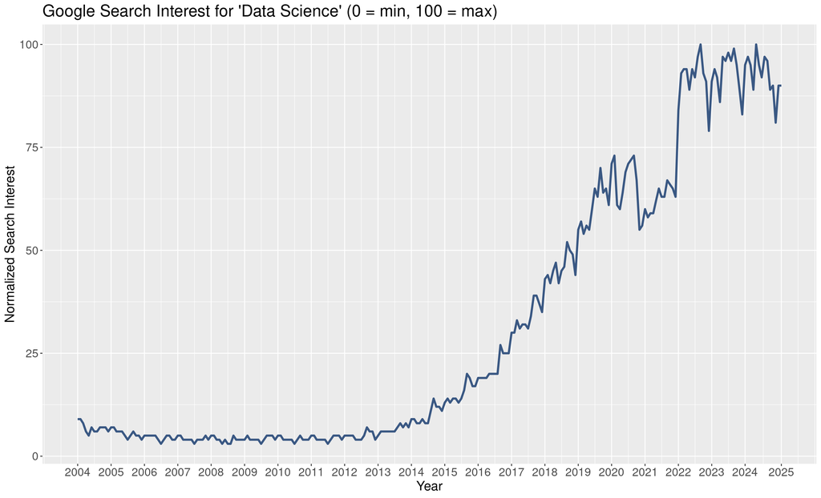

## Data Science and Artificial Intelligence (AI)

Since the arrival of ChatGPT, everyone is talking about AI…

[figure not shown]

Is Data Science = AI? How are the two related?

## Data Science and Artificial Intelligence (AI)

To answer these questions, we first need some further definitions:

- **Artificial Intelligence** (AI) is the broad field of developing machines that can replicate human behaviour, including tasks related to perception, reasoning, learning and problem-solving.
- One way of achieving this is through **Machine Learning** (ML) algorithms that detect patterns in large data sets and learn to make predictions from them.
- **Deep Learning** (DL) is an advanced branch of ML based on so-called neural networks. Innovations in this field are responsible for recent AI breakthroughs, such as ChatGPT.

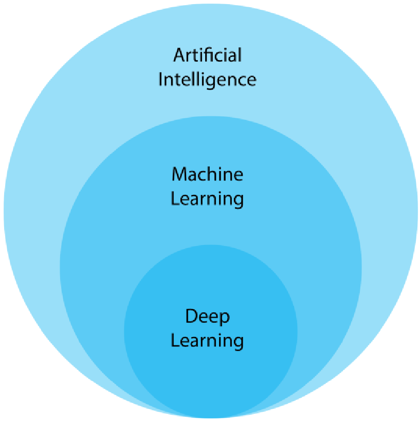

## Data Science at the heart of AI

- With all of these fields, data science has significant **overlap**, but nonetheless, constitutes its own discipline.
- Analogously, there are branches of AI (e.g. robotics or symbolic reasoning) that do *not* revolve around learning patterns from various data sources.
- Many of the advances in AI require precisely the **interdisciplinary** combination of computer science, maths, statistics and domain expertise that data science provides.
- And yet, a data scientist does much more than develop and apply algorithms for AI…

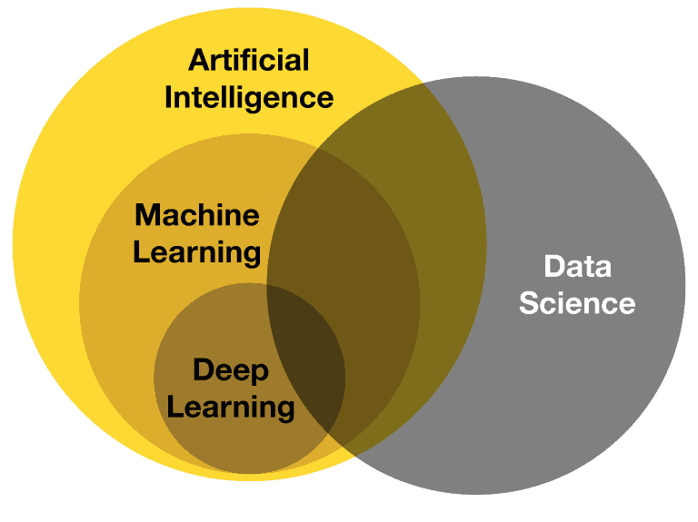

# What does a Data Scientist do?

## So what does a Data Scientist do?

- Now that we know roughly, what **data science** is, what does this discipline actually entail more concretely?
- In other words, what is it that a data scientist does every day?
- There are many ways to structure the data science, let’s first look at the **seven stages** of a data science project.

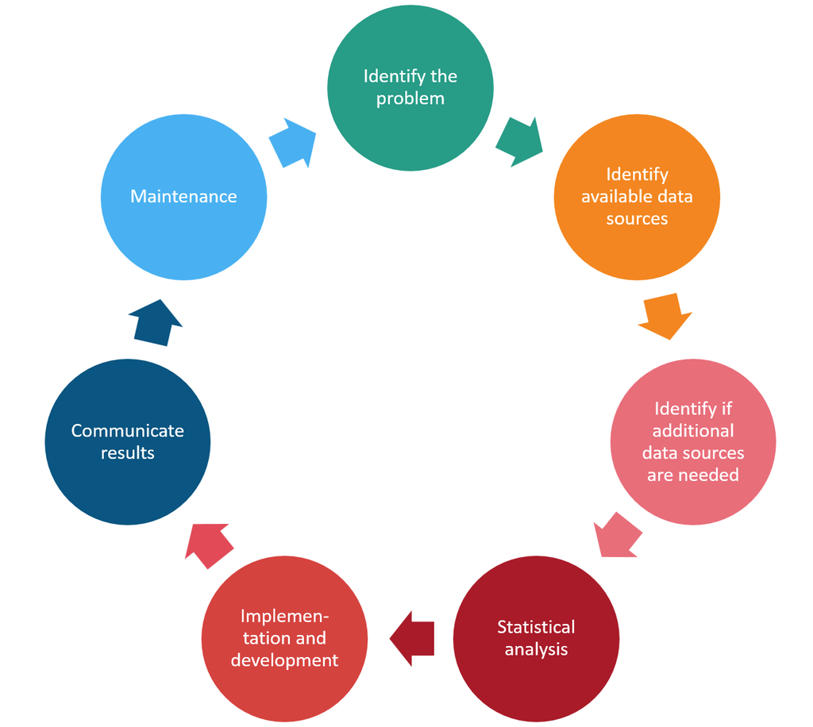

## Step 1 – Identify the problem

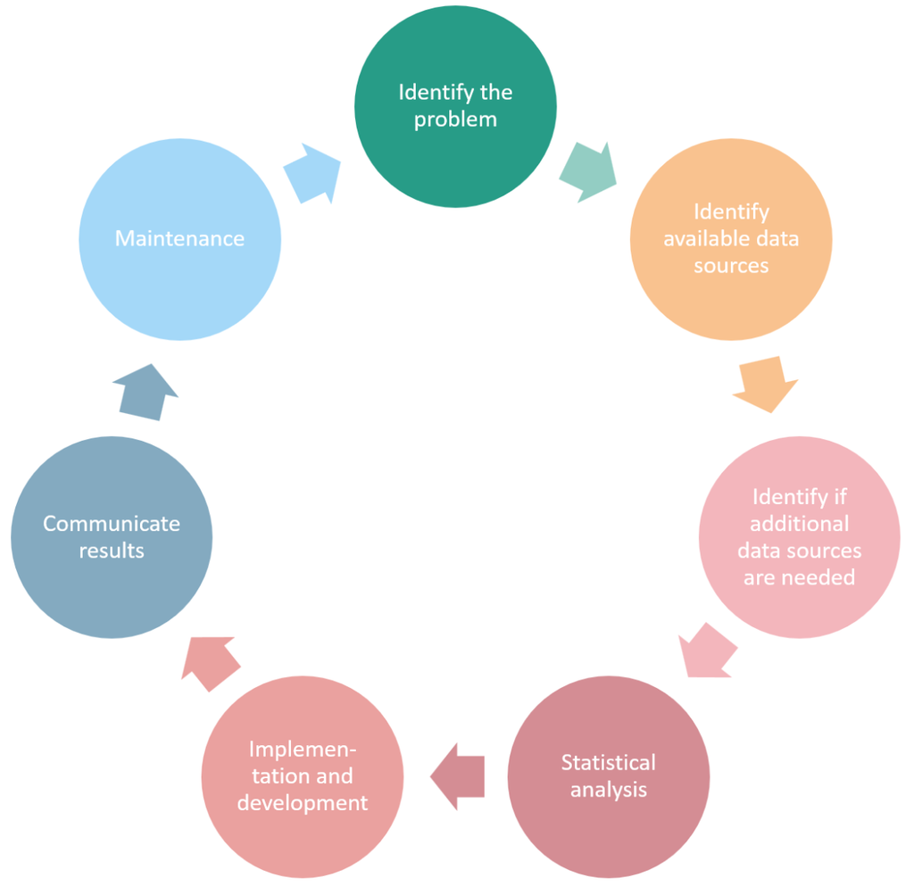

## Step 1 – Identify the problem – Key aspects

- **Understand the business context:**
  - Familiarize yourself with the industry, market trends, and internal operations.
  - **Example**: As a data scientist in a struggling e-commerce company, study industry benchmarks and analyze internal sales, user behavior, and engagement data.
- **Define the problem statement:**
  - Together with the business, clearly articulate what issue needs solving.
  - **Example**: “Our customer churn rate has increased by 20% over the last six months, impacting revenue.”
- **Identify stakeholders:**
  - Determine who is impacted and who can provide insights.
  - **Example**: *marketing* to explain and refine their existing customer engagement strategies or *customer service* to point out existing issues in post-purchase support.

## Step 1 – Identify the problem – Key aspects

- **Outline goals & objectives:**
  - In collaboration with business, specify what success looks like and define measurable KPIs.
  - **Example**: “Reduce the churn rate by 10% within the next six months.”
- **Make the goals actionable:**
  - Identify potential strategies to achieve the goals as well as the data required to implement them.
  - **Example**: train a **machine learning model** to predict customer churn and use this model to tailor new customer engagement strategies. Requires data on past customer behaviour on the website and whether or not they churned.

## Step 1 – Identify the problem – DS contributions

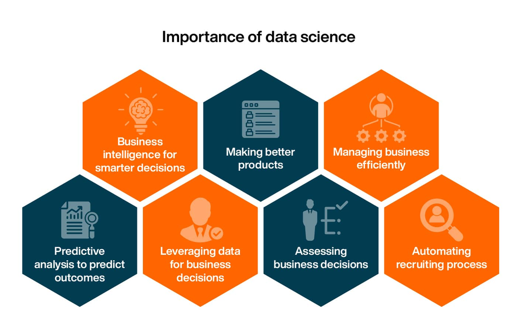

## Step 2 – Identify available data sources

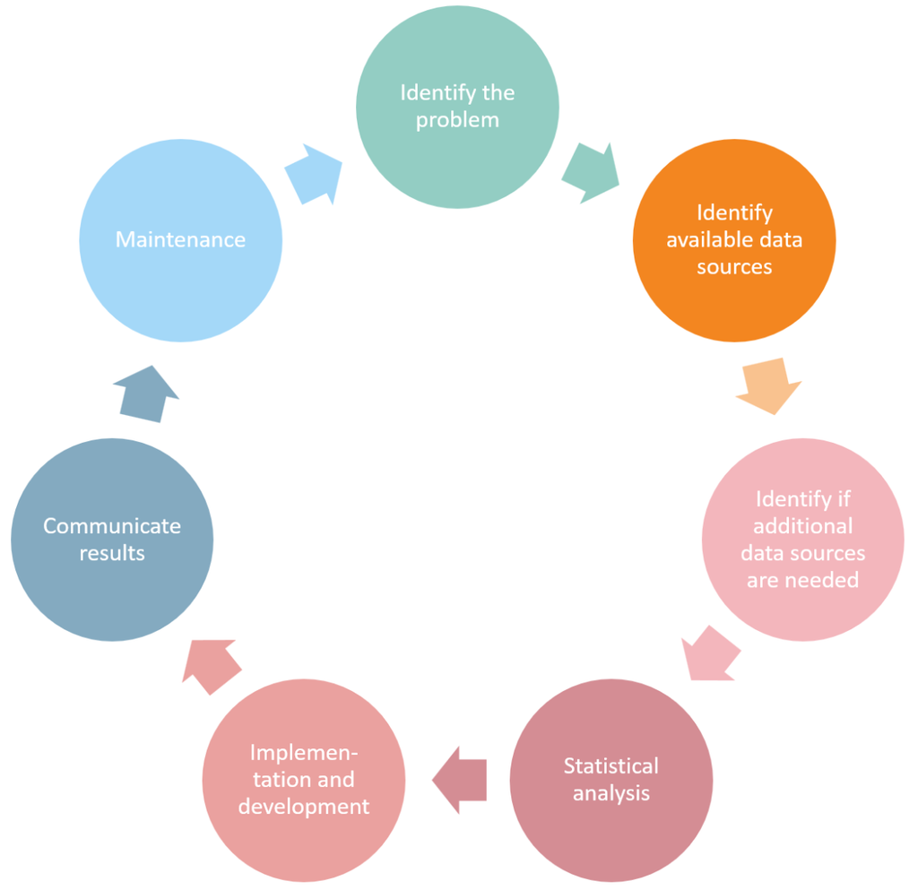

## Step 2 – Identify available data sources

- **Definition**: A **data source** refers to the physical or digital system where data is generated, stored and managed as a data table, data object or any other storage format. It is also where, stakeholders of this data (e.g. a data scientist) can access data for further use.
- **Why identify data sources early?**
  - **Foundation for analysis:** Data sources determine the quality, scope, and reliability of your insights.
  - **Strategic planning:** Knowing where data comes from helps define project goals and design the analytics pipeline.
  - **Integration & innovation:** Combining diverse sources (internal and external) can reveal hidden trends and create competitive advantages.

## Classifying data sources

**Internal sources**

- **Definition:** Data generated, stored, and maintained within the organization.
- **Examples:**
  - Enterprise systems (CRM, ERP)
  - In-house databases
  - Spreadsheets, documents, …
- **Key point:** Proprietary data that reflects your organization’s operations.

**External sources**

- **Definition:** Data sourced from outside the organization.
- **Examples:**
  - Public datasets (government statistics, market research)
  - APIs (social media, financial data feeds)
- **Key point:** Supplement internal data and provide broader market or industry insights.

## Internal data sources – CRM system

A Customer Relationship Management (CRM) system helps manage **customer data**. It helps businesses keep customer contact details up to date, track every customer interaction, and manage customer accounts.

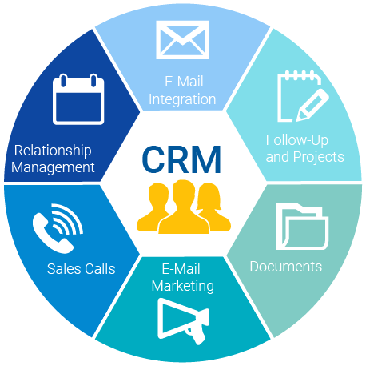

## Internal data sources – ERP system

The CRM typically forms part of the Enterprise Resource Planning (ERP) system. This type of software integrates data about **all main business processes** in a single system.

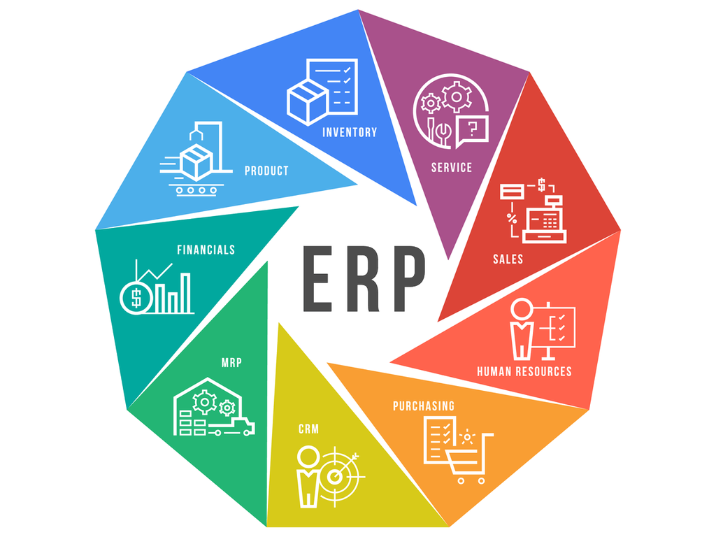

## Internal data sources – Databases

- A **database** is an organized collection of data stored and accessed electronically.
- Databases are managed using specialized software called a **Database Management System (DBMS)**, which allows users to store, retrieve, and manipulate data efficiently.
- Databases are the backbone of modern applications, supporting businesses, organizations, and systems across industries.
- Different types of databases can be classified in terms of their structure, usage, or storage methods. **Two main types** are:
  - Relational / SQL
  - NoSQL

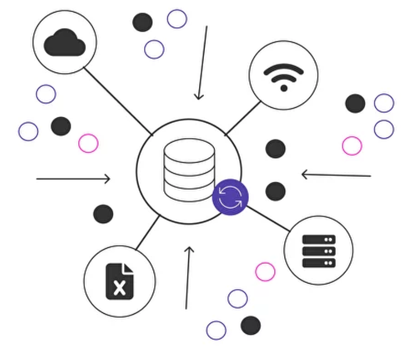

## Internal data sources – Relational databases

A **relational database** organizes data into **tables** with certain pre-defined relationships to each other. These relationships are logical connections, established on the basis of interaction among these tables.

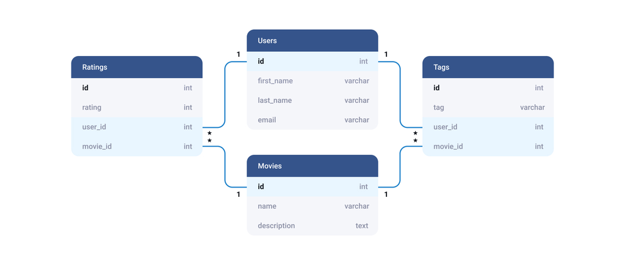

## Internal data sources – Relational databases

The **relational model** underlying such databases uses special lingo to refer to the entities that make up its structure:

| Familiar term | Relational DB term |
| --- | --- |
| Table | Relation |
| Row | Tuple |
| Column | Attribute |

[figure not shown]

- Unlike tables, relations are **unordered**, i.e. you can shuffle the order of rows or columns and still get the same relation.
- Attributes (columns) specify a **data type** (e.g. integer or text), and each tuple (or row) contains the value of that specific data type.

## Internal data sources – Relational databases

- All tables in a relational database have an attribute known as the **primary key**, which is a unique identifier of a row.
- Each row can be used to create a **relationship** between different tables using a **foreign key**, i.e. a reference to a primary key of another existing table.

Let’s see how this looks in practice: Suppose we have the following table:

[output not shown]

Clearly, the primary key in this table is **book_id**.

## Internal data sources – Relational databases

- What if “Banana Press” changed its name to “Pineapple Press”?
- We would have to change every single instance of “Banana Press” in the **Publisher** attribute. Very cumbersome…
- What if we instead organized our database like this?

[output not shown]

| Publisher_ID | Publisher | Country |
| --- | --- | --- |
| pub_1 | Banana Press | UK |
| pub_2 | Guava Press | US |

## Internal data sources – Relational databases

- We introduced the **foreign key** “Publisher_ID” into book relation.
- Now, we would just have to change the name of the publisher once, namely in the publisher relation.
- This is an example of a process called [**database normalization**](https://en.wikipedia.org/wiki/Database_normalization), which helps reduce redundancy and improve data integrity.
- To retrieve data from a relational database, one uses a specialized computer language called **Structured Query Language (SQL)**, which gives relational databases an alternative name.
- To reconstruct our original book relation, the SQL statement would be:

```sql
SELECT b.book_id, b.Title, b.Author, b.Format,
       p.Publisher, p.Country, b.Price
FROM Books AS b
LEFT JOIN Publishers AS p ON b.Publisher_ID = p.Publisher_ID
```

## Internal data sources – Relational databases

SQL will not be part of this course, but data scientists working in industry tend to write a lot of SQL…

[figure not shown]

## Internal data sources – Types of data

- Relational databases are the de-facto standard for managing **structured data**, i.e. data that is highly organized in a table-like format.
- Data can also take other forms though:
  - **Unstructured data** is not organized in a specific way and does therefore not lend itself to the relational model.
  - **Examples**: text documents, images and video.
  - **Semi-structured data** is a hybrid of the two preceding forms, containing some organizational elements (like tags or markers), but allowing for more flexibility than data stored in a relational model.
  - **Examples**: Data stored in JSON, XML or HTML files.

## Internal data sources – Types of data

For unstructured and semi-structured data, the relational model is typically not suitable, or at least suboptimal. For this purpose, **non-relational models** are preferred.

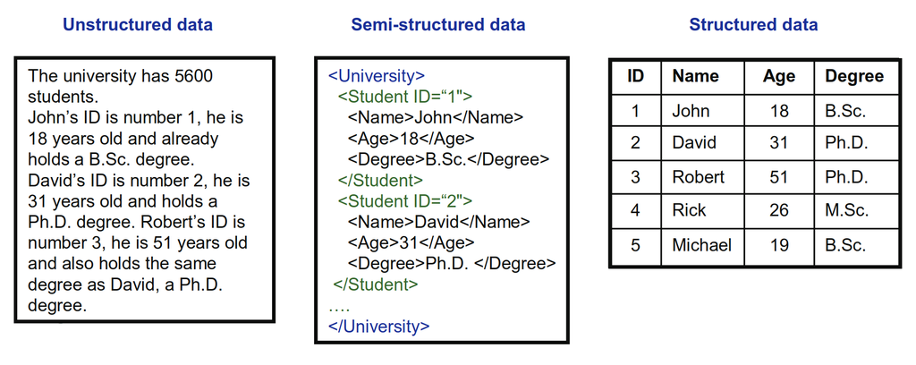

## Internal data sources – NoSQL databases

- Despite some fuzzy terminology, non-relational databases are commonly referred to as **NoSQL**.
- Types of NoSQL databases include:
  - **Key-value store**: simplest form of a NoSQL database, typically of little use in data science.
  - **Wide column store**: uses tables, rows and columns similar to relational DBs, but names and format of columns can vary from row to row.
  - **Document store**: perfect for semi-structured data, can handle complex data structures.
  - **Graph database** prioritize relationships between data objects. They use nodes (data entities) and edges (relationships) to model data.
- As an illustration of the kind of benefits achievable through NoSQL databases, we consider an example for a document store.

## Internal data sources – NoSQL databases

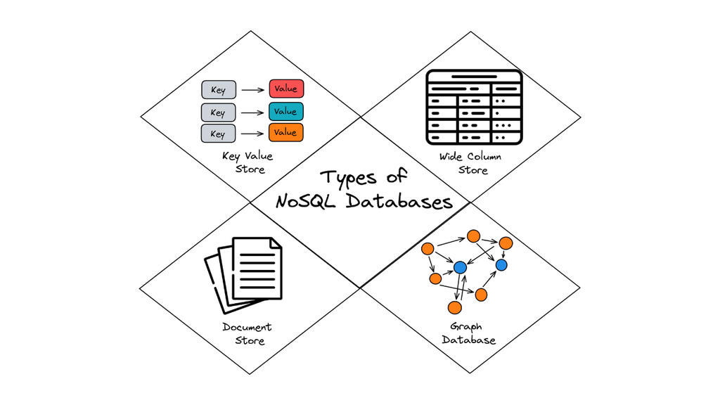

## Internal data sources – NoSQL databases

- As the name suggests, a **document store** is centred around the concept of “document”, like a JSON or XML file.
- All documents are assumed to be encoded in the same format.
- Each document has a unique key that can be used to retrieve it.
- A collection of documents could be considered analogous to a **table** in a relational database, where each row is a document. However, a collection of documents is much more **flexible**:
  - In a table, all rows must have the same sequence of columns.
  - In a collection of documents however, each document can have completely different fields.

## Internal data sources – NoSQL databases

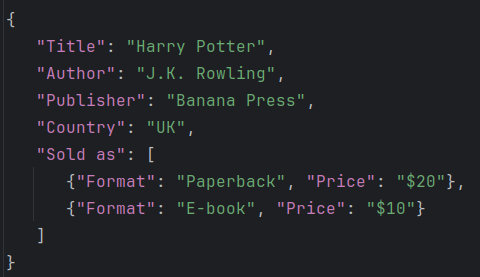

Document 1 – Harry Potter

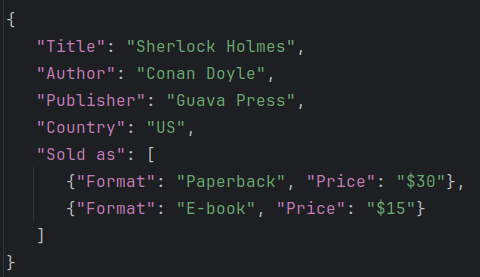

Document 2 – Sherlock Holmes

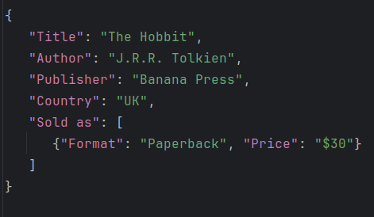

Document 3 – The Hobbit

Advantages of such a NoSQL database:

- No need to normalize
- Easier extensibility: changes in one document do not affect others.
- Better locality (all information on a document in one place instead of spread across several tables).

## Internal data sources – Others

- Unfortunately, a lot of data in corporations is *not* in a nicely structured form in a database… Instead, big amounts of data are spread around in **messy spread sheets**, e-mails, presentations, csv-files, etc.
- Organizing and cleaning such data to gain meaningful insight is a key part of being a data scientist.

[figure not shown]

## External data sources – Public data sets

- External data sources are often crucial to understand the general economic environment, market or industry trends, and much more.
- The first approach towards external data sources is usually to verify whether there are any **publicly available** data sets from reliable sources, such as:

[figure not shown]

[figure not shown]

[figure not shown]

[figure not shown]

[figure not shown]

[figure not shown]

## External data sources – APIs

- Often, rather than downloading a data set in form of a csv or xls file, data providers offer **Application Programming Interfaces (APIs)** to access their data directly.
- APIs serve as a bridge between different software applications, enabling them to communicate and share data in (near) real-time.
- As a data source, APIs can be used, for instance, to access data from…
  - … social media to detect and leverage current viral trends.
  - … AI-providers like OpenAI to incorporate information produced by ChatGPT.
  - … tech companies like Google to identify highly-rated competitors in the area based on Google Maps.
  - …

## External data sources – APIs

Let’s say you wanted to find out, how many views all of your company’s tweets on X generated last week. If your company tweets a lot, that’s a lot of manual labour… Instead, we could write a program (in R) that uses the [X API](https://docs.x.com/x-api/introduction) to gather this information.

[figure not shown]

## External data sources – APIs

- Communication with APIs works through a **request and response** cycle: the request is sent to the API, which retrieves the data and returns it to the user in form of the response.
- An API request will typically include the following components:
  - **Endpoint**: a dedicated URL declared by the API provider to access the desired resource, e.g. https://api.x.com/2/insights/historical (see [here](https://docs.x.com/x-api/posts/get-historical-metrics-for-posts)).
  - **Method**: the type of operation the client wants to perform. Data retrieval operations typically use the **GET method** (see [here](https://www.theserverside.com/blog/Coffee-Talk-Java-News-Stories-and-Opinions/HTTP-methods) for more information on HTTP methods).
  - **Parameters**: the variables indicating the specific instructions for the API to process, e.g. the time period for which you want to analyze the views of all tweets.
  - **Request headers**: meta information about the request, e.g. authentication credentials, such as an **API key**.
  - **Request body**: contains further information to be passed to the API, e.g. parameters that are not passed as part of the endpoint.

## External data sources – APIs

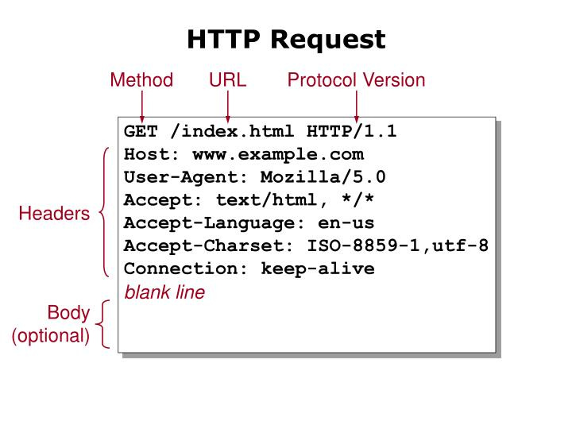

## External data sources – APIs

- The **response** returned by the API will then typically include the following components:
  - **Status code**: HTTP status codes are three-digit codes that indicate the outcome of an API request. Some common ones are:
    - 200: OK (server successfully returned the requested data)
    - 400: Bad request (e.g. malformatted request syntax)
    - 404: Not found (server cannot find requested resource)
  - **Response headers**: very similar to request headers, but provide additional information about response.
  - **Response body**: includes actual requested data, e.g. the number of views for each of last week’s tweets.

## External data sources – APIs

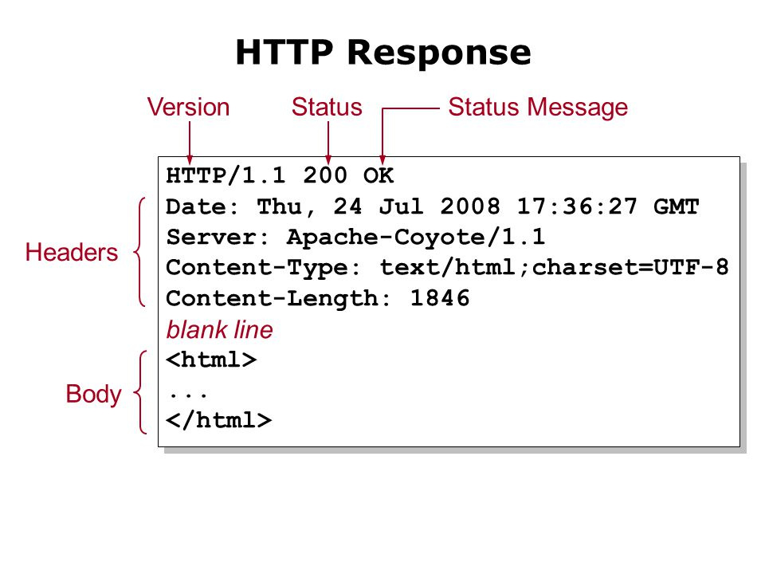